# Project_ENews_AppliedStatistics_Maitrayee

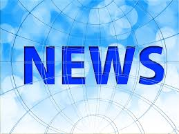

## **Problem Statement**

### **Business Context**

The advent of e-news, or electronic news, portals has offered us a great opportunity to quickly get updates on the day-to-day events occurring globally. The information on these portals is retrieved electronically from online databases, processed using a variety of software, and then transmitted to the users. There are multiple advantages of transmitting news electronically, like faster access to the content and the ability to utilize different technologies such as audio, graphics, video, and other interactive elements that are either not being used or aren’t common yet in traditional newspapers. E-news Express, an online news portal, aims to expand its business by acquiring new subscribers. With every visitor to the website taking certain actions based on their interest, the company plans to analyze these actions to understand user interests and determine how to drive better engagement. The executives at E-news Express believe that there has been a decline in new monthly subscribers compared to the past year because the current webpage is not designed well enough in terms of the outline & recommended content to keep customers engaged long enough to decide to subscribe.

[Companies often analyze user responses to two variants of a product to decide which of the two variants is more effective. This experimental technique, known as A/B testing, is used to determine whether a new feature attracts users based on a chosen metric.]

### **Objective**

The design team of the company has researched and created a new landing page that has a new outline & more relevant content compared to the old page. To test the effectiveness of the new landing page in gathering new subscribers, the Data Science team experimented by randomly selecting 100 users and dividing them equally into two groups. The existing landing page was served to the first group (control group) and the new landing page to the second group (treatment group). Data regarding the interaction of users in both groups with the two versions of the landing page was collected.

Being a data scientist in E-news Express, you have been asked to explore the data and perform a statistical analysis (at a significance level of 5%) to determine the effectiveness of the new landing page in gathering new subscribers for the news portal by answering the following questions:

1. Do the users spend more time on the new landing page than on the existing landing page?
2. Is the conversion rate (the proportion of users who visit the landing page and get converted) for the new page greater than the conversion rate for the old page?
3. Does the converted status depend on the preferred language?
4. Is the time spent on the new page the same for the different language users?

### **Data Dictionary**

The data contains information regarding the interaction of users in both groups with the two versions of the landing page. user_id - Unique user ID of the person visiting the website

- group - Whether the user belongs to the first group (control) or the second group (treatment)
- landing_page - Whether the landing page is new or old
- time_spent_on_the_page - Time (in minutes) spent by the user on the landing page
- converted - Whether the user gets converted to a subscriber of the news portal or not
- language_preferred - language chosen by the user to view the landing page

### **Solution Approach**

The solution approach will involve the following steps:

1. **Data Loading and Initial Inspection**: Load the dataset and perform an initial inspection to understand its structure, check for missing values, duplicates, and data types.
2. **Exploratory Data Analysis (EDA)**: Conduct both univariate and bivariate analyses to understand the distribution of variables, identify patterns, and visualize relationships between the `group`, `landing_page`, `time_spent_on_the_page`, `converted`, and `language_preferred` columns.
3. **Hypothesis Testing for Question 1**: Determine if users spend more time on the new landing page. This will involve:
   - Formulating null and alternative hypotheses.
   - Selection of the appropriate Hypothesis Test.
   - Checking assumptions for the chosen test.
   - Calculating the test statistic and p-value.
   - Drawing conclusions based on the p-value and a significance level of 0.05.
4. **Hypothesis Testing for Question 2**: Determine if the conversion rate for the new page is greater than for the old page. This will involve:
   - Formulating null and alternative hypotheses.
   - Selection of the appropriate Hypothesis Test.
   - Checking assumptions for the chosen test.
   - Calculating the test statistic and p-value.
   - Drawing conclusions.
5. **Hypothesis Testing for Question 3**: Investigate if the converted status depend on the preferred language.
   - Formulating null and alternative hypotheses.
   - Selection of the appropriate Hypothesis Test.
   - Checking assumptions for the chosen test.
   - Calculating the test statistic and p-value.
   - Drawing conclusions.
6. **Hypothesis Testing for Question 4**: Check if the mean time spent on the new page is the same for different language users (within the treatment group).
   - Formulating null and alternative hypotheses.
   - Selection of the appropriate Hypothesis Test.
   - Checking assumptions for the chosen test.
   - Calculating the test statistic and p-value.
   - Drawing conclusions.
7. **Actionable Insights and Conclusions**: Summarize all findings and provide practical recommendations based on the statistical analysis.

### **Analytical Approach for Selection of Hypothesis Test**:

- **Independent Samples t-test**: The selection of this statistical test would be based on the type of variables (continuous dependent, categorical independent), the number of groups, and the hypothesis (comparison of means).
- **Two-proportion One-Tailed Z-test**: The selection of the appropriate statistical test will be based on the type of variables (categorical dependent, categorical independent), the number of groups, the hypothesis (comparison of proportions), and the alternative Hypothesis (one-tailed or two-tailed).
- **Chi-square test for independence**: The selection of the appropriate statistical test will be based on the type of variables (two categorical variables) and the hypothesis (test of independence).
- **One-way ANOVA**: The selection of the appropriate statistical test will be based on the type of variables (continuous dependent, categorical independent with more than two groups) and the hypothesis (comparison of means across multiple groups).

## **Let us start by importing the required libraries**

```python
# Installing the libraries with the specified version.
!pip install numpy==2.0.2 pandas==2.2.2 matplotlib==3.10.0 seaborn==0.13.2 scipy==1.16.2 -q --user
```

**Note**: *After running the above cell, kindly restart the notebook kernel and run all cells sequentially from the start again.*

## **Import necessary packages and the data**

```python
# Libraries to help with reading and manipulating data
import numpy as np
import pandas as pd

# Libraries to help with data visualization
import seaborn as sns
import matplotlib.pyplot as plt
%matplotlib inline

# Library to help with statistical analysis
import scipy.stats as stats
```

## **Loading the dataset**

```python
# uncomment the below code cell to mount your google drive
from google.colab import drive
drive.mount('/content/drive')
```

```python
# read the dataset
path='/content/drive/MyDrive/Learnings/Python_Saved_Path/abtest.csv'
df=pd.read_csv(path)
data=df.copy()
```

## **Data Overview**

The initial steps to get an overview of any dataset is to:

- observe the first few rows of the dataset, to check whether the dataset has been loaded properly or not
- get information about the number of rows and columns in the dataset
- find out the data types of the columns to ensure that data is stored in the preferred format and the value of each property is as expected.
- check the statistical summary of the dataset to get an overview of the numerical columns of the data

#### Displaying the first few rows of the dataset

```python
# view the dataset
data.head()
```

|  | user_id | group | landing_page | time_spent_on_the_page | converted | language_preferred |
| --- | --- | --- | --- | --- | --- | --- |
| 0 | 546592 | control | old | 3.48 | no | Spanish |
| 1 | 546468 | treatment | new | 7.13 | yes | English |
| 2 | 546462 | treatment | new | 4.40 | no | Spanish |
| 3 | 546567 | control | old | 3.02 | no | French |
| 4 | 546459 | treatment | new | 4.75 | yes | Spanish |

```python
data.sample(5)
```

|  | user_id | group | landing_page | time_spent_on_the_page | converted | language_preferred |
| --- | --- | --- | --- | --- | --- | --- |
| 67 | 546582 | control | old | 4.75 | yes | Spanish |
| 83 | 546580 | control | old | 2.90 | no | Spanish |
| 97 | 546472 | treatment | new | 7.07 | yes | Spanish |
| 81 | 546449 | treatment | new | 5.26 | yes | French |
| 54 | 546482 | treatment | new | 6.41 | yes | Spanish |

#### Checking the shape of the dataset

```python
data.shape
```

```
(100, 6)
```

The dataset contains 100 rows and 6 columns.

#### Checking the data types of the columns for the dataset

```python
data.info()
```

```
<class 'pandas.core.frame.DataFrame'>
RangeIndex: 100 entries, 0 to 99
Data columns (total 6 columns):
 #   Column                  Non-Null Count  Dtype
---  ------                  --------------  -----
 0   user_id                 100 non-null    int64
 1   group                   100 non-null    object
 2   landing_page            100 non-null    object
 3   time_spent_on_the_page  100 non-null    float64
 4   converted               100 non-null    object
 5   language_preferred      100 non-null    object
dtypes: float64(1), int64(1), object(4)
memory usage: 4.8+ KB
```

There are 4 categorical columns and 2 numeric columns in the dataset.

#### Check for missing values

```python
data.isna().sum()
```

|  | 0 |
| --- | --- |
| user_id | 0 |
| group | 0 |
| landing_page | 0 |
| time_spent_on_the_page | 0 |
| converted | 0 |
| language_preferred | 0 |

**dtype:** int64

```python
data.isnull().sum()
```

|  | 0 |
| --- | --- |
| user_id | 0 |
| group | 0 |
| landing_page | 0 |
| time_spent_on_the_page | 0 |
| converted | 0 |
| language_preferred | 0 |

**dtype:** int64

```python
#checking for duplicate records in the data
data.duplicated().sum()
```

```
np.int64(0)
```

There are no missing values or duplicted records in the data.

#### Statistical summary of the dataset

```python
data.describe(include='all').T
```

|  | count | unique | top | freq | mean | std | min | 25% | 50% | 75% | max |
| --- | --- | --- | --- | --- | --- | --- | --- | --- | --- | --- | --- |
| user_id | 100.0 | NaN | NaN | NaN | 546517.0 | 52.295779 | 546443.0 | 546467.75 | 546492.5 | 546567.25 | 546592.0 |
| group | 100 | 2 | control | 50 | NaN | NaN | NaN | NaN | NaN | NaN | NaN |
| landing_page | 100 | 2 | old | 50 | NaN | NaN | NaN | NaN | NaN | NaN | NaN |
| time_spent_on_the_page | 100.0 | NaN | NaN | NaN | 5.3778 | 2.378166 | 0.19 | 3.88 | 5.415 | 7.0225 | 10.71 |
| converted | 100 | 2 | yes | 54 | NaN | NaN | NaN | NaN | NaN | NaN | NaN |
| language_preferred | 100 | 3 | Spanish | 34 | NaN | NaN | NaN | NaN | NaN | NaN | NaN |

```python
# Checking for the unique values in categorical columns
categorical=['group','landing_page','converted','language_preferred']
for i in categorical:
  print('-'*50)
  print(data[i].value_counts())
  print('-'*50)
  print('\n')
```

```
--------------------------------------------------
group
control      50
treatment    50
Name: count, dtype: int64
--------------------------------------------------


--------------------------------------------------
landing_page
old    50
new    50
Name: count, dtype: int64
--------------------------------------------------


--------------------------------------------------
converted
yes    54
no     46
Name: count, dtype: int64
--------------------------------------------------


--------------------------------------------------
language_preferred
Spanish    34
French     34
English    32
Name: count, dtype: int64
--------------------------------------------------
```

```python
# Case_id is unique for each applicant and might not add value to the rest of the analysis
data.drop(["user_id"], axis=1, inplace=True)
```

```python
print(categorical)
for i in categorical:
  data[i]=data[i].astype('category')

data.info()
```

```
['group', 'landing_page', 'converted', 'language_preferred']
<class 'pandas.core.frame.DataFrame'>
RangeIndex: 100 entries, 0 to 99
Data columns (total 5 columns):
 #   Column                  Non-Null Count  Dtype
---  ------                  --------------  -----
 0   group                   100 non-null    category
 1   landing_page            100 non-null    category
 2   time_spent_on_the_page  100 non-null    float64
 3   converted               100 non-null    category
 4   language_preferred      100 non-null    category
dtypes: category(4), float64(1)
memory usage: 1.8 KB
```

```python
# Beginning the Analysis by clearly identifying the numerical and categorical columns
num_cols = data.select_dtypes(include=np.number).columns.tolist()
cat_cols = data.select_dtypes(include="category").columns.tolist()
print(f"Numerical Columns: {num_cols}")
print(f"Categorical Columns: {cat_cols}")
```

```
Numerical Columns: ['time_spent_on_the_page']
Categorical Columns: ['group', 'landing_page', 'converted', 'language_preferred']
```

```python
data.describe(include='all').T
```

|  | count | unique | top | freq | mean | std | min | 25% | 50% | 75% | max |
| --- | --- | --- | --- | --- | --- | --- | --- | --- | --- | --- | --- |
| group | 100 | 2 | control | 50 | NaN | NaN | NaN | NaN | NaN | NaN | NaN |
| landing_page | 100 | 2 | new | 50 | NaN | NaN | NaN | NaN | NaN | NaN | NaN |
| time_spent_on_the_page | 100.0 | NaN | NaN | NaN | 5.3778 | 2.378166 | 0.19 | 3.88 | 5.415 | 7.0225 | 10.71 |
| converted | 100 | 2 | yes | 54 | NaN | NaN | NaN | NaN | NaN | NaN | NaN |
| language_preferred | 100 | 3 | French | 34 | NaN | NaN | NaN | NaN | NaN | NaN | NaN |

## Observations

- The user_id is a column consisting of unique user-ids. This is of no consequence for the current study and, hence, has been dropped later.
- The mean engagement-time is 5.3778 minutes, while the median engagement-time is 5.415 minutes.
- There are 2 groups (**control** and **treatment**), with equal no of samples in each, who are getting the **old** and **new** landing pages respectively.
- There are 3 unique values for language and 2 unique values for converted columns.

## Exploratory Data Analysis

### Univariate Analysis

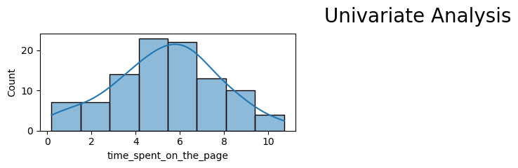

```python
col_names = data.columns.tolist()


# getting all the Histograms for the parameters
plt.figure(figsize=(12,10))
plt.suptitle('Univariate Analysis',fontsize=20)
for i,attribute in enumerate(num_cols):
  plt.subplot(5,3,i+1)
  sns.histplot(data=data,x=attribute,kde=True)
plt.tight_layout()
plt.show()
```

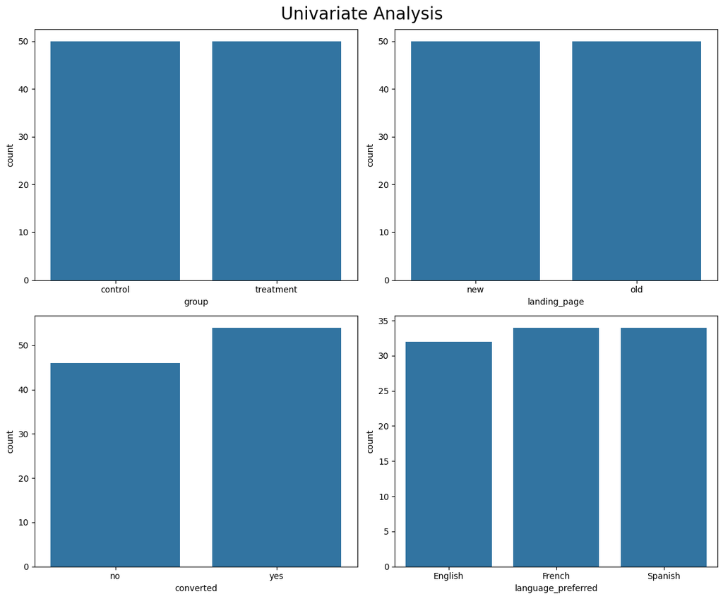

```python
# getting all the Countplots for the parameters
plt.figure(figsize=(12,10))
plt.suptitle('Univariate Analysis',fontsize=20)
for i,attribute in enumerate(cat_cols):
  plt.subplot(2,2,i+1)
  sns.countplot(data=data,x=attribute)
plt.tight_layout()
plt.show()
```

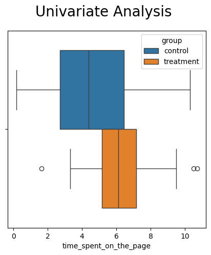

```python
#creating a boxplot of Product_Store_Sales_Total
plt.figure(figsize=(5,5))
plt.suptitle('Univariate Analysis',fontsize=20)
sns.boxplot(data,x='time_spent_on_the_page',hue='group')
plt.show()
```

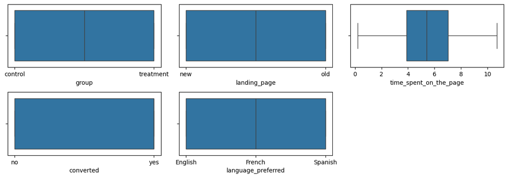

```python
# getting all the Boxplots for the parameters
plt.figure(figsize=(12,10))
for i,attribute in enumerate(col_names):
  plt.subplot(5,3,i+1)
  sns.boxplot(data=data,x=attribute)
plt.tight_layout()
plt.show()
```

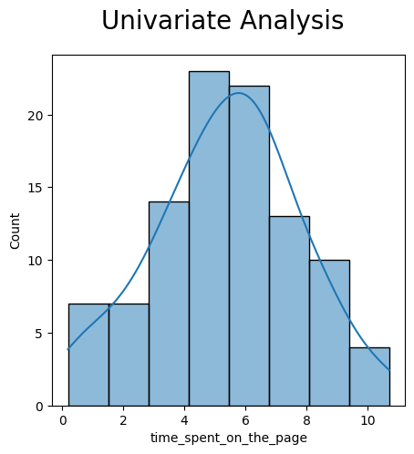

```python
#creating a histplot for time_spent_on_the_page
plt.figure(figsize=(5,5))
plt.suptitle('Univariate Analysis',fontsize=20)
sns.histplot(data=data,x='time_spent_on_the_page',kde=True)
```

### Observations

#### Observations from Univariate Analysis

- The `time_spent_on_the_page` column appears to be somewhat symmetrically distributed, with a mean of approximately 5.38 minutes and a median of 5.42 minutes. The range is from 0.19 to 10.71 minutes.
- There are an equal number of users (50 each) in the `control` and `treatment` groups.
- Similarly, there are an equal number of `old` and `new` `landing_page` views (50 each).
- More users were `converted` (54) than `not converted` (46).
- The `language_preferred` distribution is fairly balanced, with Spanish (34) and French (34) having slightly more users than English (32).

### Bivariate Analysis

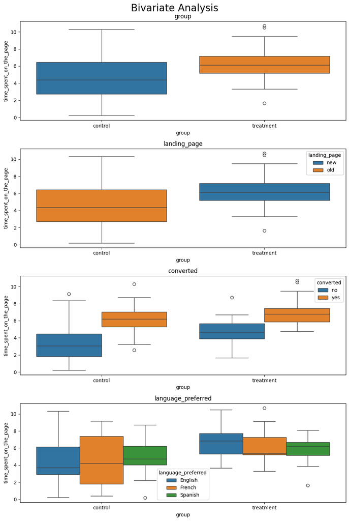

```python
plt.figure(figsize=(10,15))
plt.suptitle('Bivariate Analysis',fontsize=20)
for i, feature in enumerate(cat_cols):
    plt.subplot(4,1,i+1)
    sns.boxplot(data,x='group',y='time_spent_on_the_page',hue=feature)
    plt.title(feature)
plt.tight_layout()
plt.show()
```

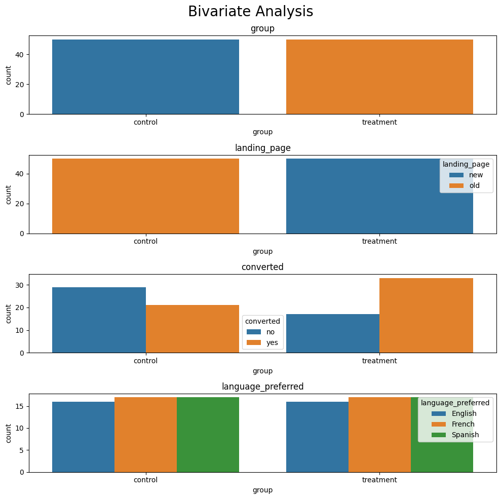

```python
#Plotting groups vs conversion
plt.figure(figsize=(10,10))
plt.suptitle('Bivariate Analysis',fontsize=20)
for i, feature in enumerate(cat_cols):
    plt.subplot(4,1,i+1)
    sns.countplot(data,x='group',hue=feature)
    plt.title(feature)
plt.tight_layout()
plt.show()
```

### Observations

#### Observations from Bivariate Analysis

- **Group and Landing Page vs. Time Spent**: Users in the `treatment` group (exposed to the `new` landing page) generally spent more time on the page compared to users in the `control` group (exposed to the `old` landing page). The median time spent for the `treatment` group appears higher, suggesting the new page might be more engaging.
- **Converted Status vs. Time Spent**: Across both `control` and `treatment` groups, users who `converted` (`yes`) tend to have spent considerably more time on the page than those who `not converted` (`no`). This indicates a positive correlation between time spent and conversion.
- **Language Preferred vs. Time Spent (within groups)**: The time spent on the page appears to be relatively consistent across different `language_preferred` categories within each `group` (control/treatment). There might be minor variations, but no drastically different patterns are immediately obvious, suggesting language preference might not be a strong predictor of time spent, at least in a simple bivariate context.
- **Group vs. Landing Page**: As expected from the experimental setup, all users in the `control` group were shown the `old` landing page, and all users in the `treatment` group were shown the `new` landing page.
- **Group vs. Converted Status**: In the `control` group, there were more users who `not converted` compared to those who `converted`. Conversely, in the `treatment` group, there were more users who `converted` compared to those who `not converted`. This visually suggests that the new landing page (treatment group) might lead to a higher conversion rate.
- **Group vs. Language Preferred**: The distribution of `language_preferred` (English, Spanish, French) appears to be well-balanced and similar between the `control` and `treatment` groups, indicating a successful randomization of participants based on language preference.

## **Question 1: Do the users spend more time on the new landing page than the old landing page?**

To visualize the distribution of time-spent-on-page, we can plot a distribution plot.

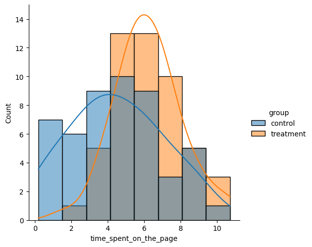

```python
# plot the distribution plot of time-spent-on-the-page
plt.figure(figsize=(5,5))
sns.displot(data=data, x='time_spent_on_the_page', kde=True, hue='group')
plt.show()
```

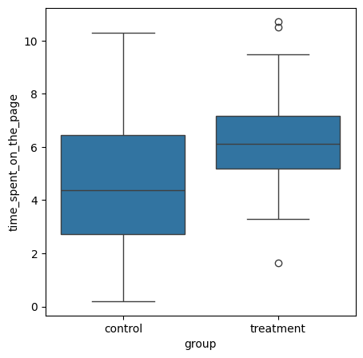

```python
# plot the boxplot of time-spent-on-the-page by the users of control and treatment groups
plt.figure(figsize=(5,5))
sns.boxplot(data=data, x='group', y='time_spent_on_the_page')
plt.show()
```

#### Another relevant visualization: Bar Plot of Mean Time Spent with Confidence Intervals

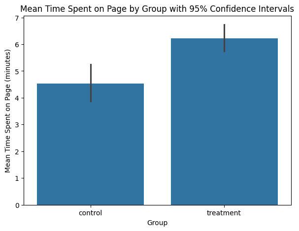

```python
plt.figure(figsize=(7, 5))
sns.barplot(x='group', y='time_spent_on_the_page', data=data, errorbar=('ci',95))
plt.title('Mean Time Spent on Page by Group with 95% Confidence Intervals')
plt.xlabel('Group')
plt.ylabel('Mean Time Spent on Page (minutes)')
plt.show()
```

#### Observations from Bar Plot of Mean Time Spent

- The bar plot clearly shows that the mean `time_spent_on_the_page` for the `treatment` group is higher than for the `control` group.
- The confidence intervals (error bars) for the two groups do not overlap, which visually suggests a statistically significant difference between the means. This supports the hypothesis that the new landing page leads to increased user engagement in terms of time spent.

### **Step 1: Define null and alternative hypotheses**

Let's frame the null and alternative hypothesis

> $H_0:$ The mean time_spent_on_the_page of Control group is equal to that of Treatment group.

> $H_a:$ The mean time_spent_on_the_page of Control group is less than that of Treatment group.

Let $\mu_1$ be the mean app engagement time of Control group Let $\mu_2$ be the mean app engagement time of Treatment group

Mathematically, the above formulated hypotheses can be written as:

> $H_0: \mu_1 \ge \mu_2 $  
> $H_a: \mu_1 < \mu_2 $

```python
# find the sample means and sample standard deviations for the two groups
control_mean = data[data['group'] == 'control']['time_spent_on_the_page'].mean()
treatment_mean = data[data['group'] == 'treatment']['time_spent_on_the_page'].mean()
print("Control Group Mean:",control_mean)
print("Treatment Group Mean:",treatment_mean)
print("-----------------------")
control_sd = data[data['group'] == 'control']['time_spent_on_the_page'].std()
treatment_sd = data[data['group'] == 'treatment']['time_spent_on_the_page'].std()
print("Control Group Standard Deviation:",control_sd)
print("Treatment Group Standard Deviation:",treatment_sd)
```

```
Control Group Mean: 4.532400000000001
Treatment Group Mean: 6.2232
-----------------------
Control Group Standard Deviation: 2.581974849306046
Treatment Group Standard Deviation: 1.8170310387878263
```

### **Step 2: Select Appropriate test**

This is a case of a one-tailed test for the comparison of the mean for 2 independent groups. As the standard deviations of the two groups are different, selecting the **2-sample independent t-test** for the Hypothesis test as the appropriate one.

**Let's test whether the T-test assumptions are satisfied or not**

- Continuous data - Yes, the usage time is measured on a continuous scale.
- Normally distributed populations - Yes, the groups each have sample size of 50 (n>30) and, hence, can be taken to be normal distributions
- Independent populations - As we are taking random samples for two different type of users, the two samples are from two independent populations.
- Unequal population standard deviations - As the sample standard deviations are different, the population standard deviations may be assumed to be different.
- Random sampling from the population - Yes, we are informed that the collected samples are random samples.

We can use two sample T-test for this problem.

### Prepare the Data for the 2-Sample Independent t-test

```python
#Fetch the time_spent_on_the_page by the control group into a new series
control_group_time = data[data['group'] == 'control']['time_spent_on_the_page']
treatment_group_time = data[data['group'] == 'treatment']['time_spent_on_the_page']
print(control_group_time.head(5))
print(treatment_group_time.head(5))
```

```
0    3.48
3    3.02
5    5.28
7    6.53
9    2.08
Name: time_spent_on_the_page, dtype: float64
1     7.13
2     4.40
4     4.75
6     5.25
8    10.71
Name: time_spent_on_the_page, dtype: float64
```

### **Step 3: Decide the significance level**

As mentioned in the Business Context the level of significane (alpha) has been decided as 0.05

### **Step 4: Calculate the p-value**

The ttest_ind() function of Scipy will be used to compute the test statistic and p-value.

```python
#import the required functions
from scipy.stats import ttest_ind

# find the p-value
test_stat, p_value = ttest_ind(control_group_time, treatment_group_time, equal_var = False, alternative = 'less')
print('The p-value is ', p_value)
```

```
The p-value is  0.0001392381225166549
```

### **Step 5: Compare the p-value with $\alpha$ (level of significance)**

```python
# print the conclusion based on p-value
if p_value < 0.05:
    print(f'As the p-value {p_value} is less than the level of significance, we reject the null hypothesis.')
else:
    print(f'As the p-value {p_value} is greater than the level of significance, we fail to reject the null hypothesis.')
```

```
As the p-value 0.0001392381225166549 is less than the level of significance, we reject the null hypothesis.
```

### **Step 6: Draw Inference**

Since the p-value is less than the 5% significance level, we reject the null hypothesis. Hence, we have enough statistical evidence to say that the mean time_spent_on_the_page of the control group is less than that of the treatment group.

In other words, users are, on an average, spending more time on the new landing page than the old landing page.

## **Question 2: Is the conversion rate (the proportion of users who visit the landing page and get converted) for the new page greater than the conversion rate for the old page?**

```python
#fetching the count of converted='yes' users by group
data.groupby(['group','converted'])['converted'].count()
```

| group | converted | converted |
| --- | --- | --- |
| control | no | 29 |
|  | yes | 21 |
| treatment | no | 17 |
|  | yes | 33 |

**dtype:** int64

Since both the concerned variables (group,converted) are categorical in nature, we can use a contingency table and a stacked bar graph to visually inspect the data.

The pandas [crosstab()](https://pandas.pydata.org/docs/reference/api/pandas.crosstab.html) function is used to create a contingency table between two categorical variables from a dataframe. The syntax of the function is:

`pd.crosstab(index, columns, margins=False, normalize=False)`

where

- *index*: Values to group by in the rows
- *columns*: Values to group by in the columns
- *margins*: Whether to add row/column sub-totals. Default value is False
- *normalize*: Whether to normalize the value-counts. Default value is False

```python
# create a contingency table to tabulate the frequencies of group and converted
contingency_table = pd.crosstab(data.group, data.converted)
contingency_table
```

| converted group | no | yes |
| --- | --- | --- |
| control | 29 | 21 |
| treatment | 17 | 33 |

To visualize the relationship between the two categorical variables, we can plot a stacked bar chart.

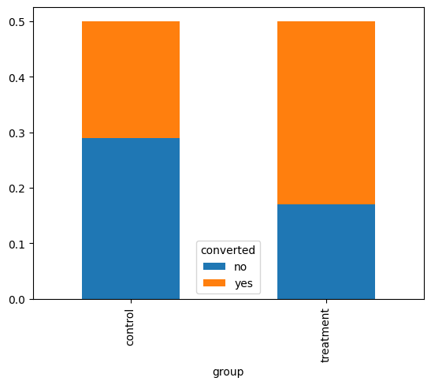

```python
# visual analysis
pd.crosstab(data.group, data.converted,normalize=True).plot(kind='bar',stacked=True)
```

### Observations

#### Observations from Contingency Table and Stacked Bar Chart

- **Control Group Conversion**: In the control group (old landing page), 21 out of 50 users converted, which is a conversion rate of 42%.
- **Treatment Group Conversion**: In the treatment group (new landing page), 33 out of 50 users converted, resulting in a conversion rate of 66%.
- **Comparison**: The treatment group exhibits a substantially higher conversion rate (66%) compared to the control group (42%). This visual analysis suggests that the new landing page is more effective in converting users into subscribers.

### **Step 1: Define null and alternative hypotheses**

**Let's formulate the null and alternative hypothesis for the above problem**

$H_0:$ The conversion rate of the control group is greater than or equal compared to treatment group

$H_a:$ The conversion rate of the control group is lesser than the treatment group

Let $p1,p2$ be the proportions of converted users from the control and treatment groups respectively.

> $H_0:p_1 \ge p_2$

against the alternate hypothesis

> $H_a:p_1 < p_2$

### **Step 2: Select Appropriate test**

To test whether the conversion frequency is greater for the treatment group compared to the control group, a **Two-proportion one-tailed z-test** is being selected.

### Let's test whether the Z-test assumptions are satisfied or not

- Binomally distributed population - Yes, a user is either converted or not.
- Random sampling from the population - Yes, we are informed that the collected sample is a simple random sample.
- Can the binomial distribution approximated to normal distribution - Yes. For binary data, CLT works slower than usual. The standard thing is to check whether np and n(1-p) are greater than or equal to 10. Here, n and p refer to the sample size and sample proportion respectively.

  > $np_1 = 50\cdot \frac{21}{50} =21 \geq 10\\ n(1-p_1) = 50 \cdot \frac{50-21}{50} =29 \geq 10 \\ np_2 = 50\cdot \frac{33}{50} =33 \geq 10\\ n(1-p_2) = 50 \cdot \frac{50-33}{50} =17 \geq 10 $

### **Step 3: Decide the significance level**

As mentioned in the Business Context the level of significane (alpha) has been decided as 0.05

### **Step 4: Collect and prepare data**

Let's prepare the data for the test.

```python
# prepare the data for the 2-proportion z-test
contingency_table
```

| converted group | no | yes |
| --- | --- | --- |
| control | 29 | 21 |
| treatment | 17 | 33 |

### **Step 5: Calculate the p-value**

This test uses the proportions_ztest() function. The function will be used for comparing two proportions.

```python
# import the required fuction
from statsmodels.stats.proportion import proportions_ztest

# set the counts of converted users for control and treatment groups
converted_count = np.array([21, 33])

# set the sample sizes
nobs = np.array([50, 50])

# find the p-value
test_stat, p_value = proportions_ztest(converted_count, nobs, alternative='smaller')
print('The p-value is ' + str(p_value))
```

```
The p-value is 0.008026308204056278
```

### **Step 6: Compare the p-value with $\alpha$**

```python
# print the conclusion based on p-value
if p_value < 0.05:
    print(f'As the p-value {p_value} is less than the level of significance, we reject the null hypothesis.')
else:
    print(f'As the p-value {p_value} is greater than the level of significance, we fail to reject the null hypothesis.')
```

```
As the p-value 0.008026308204056278 is less than the level of significance, we reject the null hypothesis.
```

### **Step 7: Draw inference**

Since the p-value is less than the 5% significance level, we reject the null hypothesis.

Hence, we have enough statistical evidence to say that the treatment group has a higher conversion proportion compared to the control group.

## **Question 3: Does the converted status depend on the preferred language?**

```python
#fetching the count of converted='yes' users by language_preferred
data.groupby(['language_preferred','converted'])['converted'].count()
```

| language_preferred | converted | converted |
| --- | --- | --- |
| English | no | 11 |
|  | yes | 21 |
| French | no | 19 |
|  | yes | 15 |
| Spanish | no | 16 |
|  | yes | 18 |

**dtype:** int64

Since both the concerned variables (language_preferred,converted) are categorical in nature, we can use a contingency table and a stacked bar graph to visually inspect the data.

```python
# create a contingency table to tabulate the frequencies of group and converted
contingency_table_2 = pd.crosstab(data.language_preferred, data.converted)
contingency_table_2
```

| converted language_preferred | no | yes |
| --- | --- | --- |
| English | 11 | 21 |
| French | 19 | 15 |
| Spanish | 16 | 18 |

To visualize the relationship between the two categorical variables, we can plot a stacked bar chart.

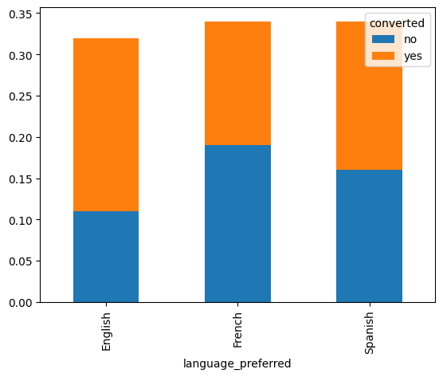

```python
# visual analysis
pd.crosstab(data.language_preferred, data.converted,normalize=True).plot(kind='bar',stacked=True)
```

### **Step 1: Define null and alternative hypotheses**

**Let's formulate the null and alternative hypothesis for the above problem**

Let p1,p2,p3 be the proportions of converted users for English, French and Spanish respectively.

We will test the null hypothesis

> $H_0: p1 = p2 = p3$

against the alternative hypothesis

> $H_a: $ At least one language group's conversion proportion is different from the rest.

### **Step 2: Select Appropriate test**

To test the dependence between two categorical variables, a Chi-square test for independence is used.

### Let's test whether the assumptions are satisfied or not

- Categorical variables - Yes
- Expected value of the number of sample observations in each level of the variable is at least 5 - Yes, the number of observations in each level is greater than 5.
- Random sampling from the population - Yes, we are informed that the collected sample is a random sample.

### **Step 3: Decide the significance level**

As mentioned in the Business Context the level of significane (alpha) has been decided as 0.05

### **Step 4: Collect and prepare data**

Let's prepare the data for the test. To perform the chi-squared test of independance, we need to create the contingency table, for which we will use `pd.crosstab()`

```python
# prepare a contingency table to perform the test
contingency_table_2
```

| converted language_preferred | no | yes |
| --- | --- | --- |
| English | 11 | 21 |
| French | 19 | 15 |
| Spanish | 16 | 18 |

### **Step 5: Calculate the p-value**

We will use the `chi2_contingency` function from the scipy stats library to perform the hypothesis test. It takes the contingency table as an input and returns the test statistic, p-value, degrees of freedom, and the expected frequencies as the output.

```python
# import the required test function
from scipy.stats import chi2_contingency

# calculate the test results
chi, p_value, dof, expected = chi2_contingency(contingency_table_2)

print("Test Statistic =",chi)
print("p-value =",p_value)
print("Degrees of freedom =",dof)
print("Expected frequencies \n", expected)
```

```
Test Statistic = 3.0930306905370832
p-value = 0.2129888748754345
Degrees of freedom = 2
Expected frequencies
 [[14.72 17.28]
 [15.64 18.36]
 [15.64 18.36]]
```

### **Step 6: Compare the p-value with $\alpha$**

```python
# print the conclusion based on p-value
if p_value < 0.05:
    print(f'As the p-value {p_value} is less than the level of significance, we reject the null hypothesis.')
else:
    print(f'As the p-value {p_value} is greater than the level of significance, we fail to reject the null hypothesis.')
```

```
As the p-value 0.2129888748754345 is greater than the level of significance, we fail to reject the null hypothesis.
```

## **Question 4: Is the mean time spent on the new page same for the different language users?**

```python
#fetching the time_spent_on_the_page grouped by language_preferred for the treatment group only
data[data['group']=='treatment'].groupby(['language_preferred'])['time_spent_on_the_page'].mean()
```

| language_preferred | time_spent_on_the_page |
| --- | --- |
| English | 6.663750 |
| French | 6.196471 |
| Spanish | 5.835294 |

**dtype:** float64

### Visualizing the data

```
(50, 5)
        group landing_page  time_spent_on_the_page converted  \
98  treatment          new                    6.20       yes
13  treatment          new                    6.03       yes
47  treatment          new                    7.23       yes
99  treatment          new                    5.86       yes
97  treatment          new                    7.07       yes

   language_preferred
98            Spanish
13             French
47            Spanish
99            English
97            Spanish
```

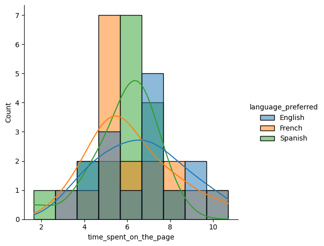

```python
# plot the distribution plot of time-spent-on-the-page segregated by language_preferred for the treatment group only
df_t = data[data['group']=='treatment']
print(df_t.shape)
print(df_t.sample(5))

plt.figure(figsize=(5,5))
sns.displot(data=df_t, x='time_spent_on_the_page', kde=True, hue='language_preferred')
plt.show()
```

```python
data[data['group']=='treatment'].groupby(['language_preferred'])['time_spent_on_the_page'].describe()
```

| language_preferred | count | mean | std | min | 25% | 50% | 75% | max |
| --- | --- | --- | --- | --- | --- | --- | --- | --- |
| English | 16.0 | 6.663750 | 1.984150 | 3.65 | 5.3275 | 6.865 | 7.7125 | 10.50 |
| French | 17.0 | 6.196471 | 1.933394 | 3.30 | 5.2500 | 5.420 | 7.2700 | 10.71 |
| Spanish | 17.0 | 5.835294 | 1.525656 | 1.65 | 5.1500 | 6.200 | 6.7000 | 8.08 |

### Let's write the null and alternative hypothesis

Let $\mu_1, \mu_2, \mu_3$ be the means of time_spent_on_the_page by users in the treatment group with the preferred language English, French and Spanish respectively.

We will test the null hypothesis

> $H_0: \mu_1 = \mu_2 = \mu_3$

against the alternative hypothesis

> $H_a: $ At least one mean time_spent_on_the_page is different from the rest.

```
language_preferred
English    6.663750
French     6.196471
Spanish    5.835294
Name: time_spent_on_the_page, dtype: float64
```

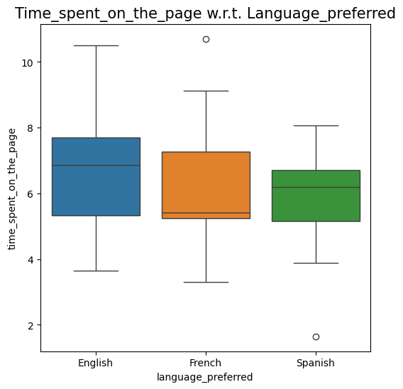

```python
# mean of carbon emission at different levels of the fuel_type factor
print(data[data['group']=='treatment'].groupby(['language_preferred'])['time_spent_on_the_page'].mean())

# draw the boxplot for visualization
fig, ax = plt.subplots(figsize = (6,6))
a = sns.boxplot(x= "language_preferred", y = 'time_spent_on_the_page' , data = df_t, hue = 'language_preferred')
a.set_title("Time_spent_on_the_page w.r.t. Language_preferred", fontsize=15)
plt.show()
```

Now, the normality and equality of variance assumptions need to be checked.

For testing of normality, Shapiro-Wilk’s test is applied to the response variable.

For equality of variance, Levene test is applied to the response variable.

### Shapiro-Wilk’s test

We will test the null hypothesis

> $H_0:$ Time_Spent_on_the_page follows a normal distribution against

against the alternative hypothesis

> $H_a:$ Time_Spent_on_the_page does not follow a normal distribution

```python
# Assumption 1: Normality
# import the required function
from scipy import stats

# find the p-value
w, p_value = stats.shapiro(df_t['time_spent_on_the_page'])
print('The p-value is', p_value)
```

```
The p-value is 0.8040040364746845
```

Since p-value of the test is very large, we fail to reject the null hypothesis that the response follows the normal distribution.

### Levene’s test

We will test the null hypothesis

> $H_0$: All the population variances are equal

against the alternative hypothesis

> $H_a$: At least one variance is different from the rest

```python
#Assumption 2: Homogeneity of Variance
#import the required function
from scipy.stats import levene
statistic, p_value = levene( df_t['time_spent_on_the_page'][df_t['language_preferred']=="English"],
                                   df_t['time_spent_on_the_page'][df_t['language_preferred']=="French"],
                                   df_t['time_spent_on_the_page'][df_t['language_preferred']=="Spanish"])
# find the p-value
print('The p-value is', p_value)
```

```
The p-value is 0.46711357711340173
```

Since the p-value is large, we fail to reject the null hypothesis of homogeneity of variances.

Let's test whether the assumptions are satisfied or not

- The populations are normally distributed - Yes, the normality assumption is verified using the Shapiro-Wilk’s test.
- Samples are independent simple random samples - Yes, we are informed that the collected sample is a simple random sample.
- Population variances are equal - Yes, the homogeneity of variance assumption is verified using the Levene's test.

### Let's find the p-value

The [`f_oneway()`](https://docs.scipy.org/doc/scipy/reference/generated/scipy.stats.f_oneway.html) function of Scipy will be used to compute the test statistic and p-value.

```python
#import the required function
from scipy.stats import f_oneway

# perform one-way anova test
test_stat, p_value = f_oneway(df_t.loc[df_t['language_preferred'] == 'English', 'time_spent_on_the_page'],
                              df_t.loc[df_t['language_preferred'] == 'French', 'time_spent_on_the_page'],
                              df_t.loc[df_t['language_preferred'] == 'Spanish', 'time_spent_on_the_page'])
print('The p-value is ' + str(p_value))
```

```
The p-value is 0.43204138694325955
```

### Comparing the p-value with $\alpha$

```python
# print the conclusion based on p-value
if p_value < 0.05:
    print(f'As the p-value {p_value} is less than the level of significance, we reject the null hypothesis.')
else:
    print(f'As the p-value {p_value} is greater than the level of significance, we fail to reject the null hypothesis.')
```

```
As the p-value 0.43204138694325955 is greater than the level of significance, we fail to reject the null hypothesis.
```

### Draw inference

As the p-value is much higher than the significance level, we fail to reject the null hypothesis. Hence, based on the statistical evidence we cannot conclude that the mean time spent differs across language preferences for the users of the new landing page.

## **Actionable Insights and Conclusions**

### **Actionable Insights**

1. New Landing Page vs. Old Landing Page (Engagement and Conversion):

**Key Finding:** The new landing page (treatment group) significantly outperforms the old landing page (control group) in two critical aspects:

- *Time Spent:* Users, on average, spend more time on the new landing page. The statistical test confirmed that the mean time spent on the new page is greater than on the old page.
- *Conversion Rate:* The two-proportion z-test confirmed that the conversion rate for the new landing page (66%) is significantly higher than for the old landing page (42%). Users of the new landing page spend more time on the page and convert more frequently.

*Actionable Insight:* Strongly recommend implementing the new landing page across all user segments. It is demonstrably more engaging and effective in converting users into subscribers. This change should directly contribute to the company's objective of acquiring more subscribers.

1. Language Preferred and Conversion Status:

**Key Finding:** The analysis found no significant statistical evidence to suggest that conversion rates depend on the preferred language. While some visual differences were observed (English users showed a higher conversion rate in the sample), these differences were not statistically significant.

*Actionable Insight:* Based on this data, there is no immediate need to tailor conversion strategies or landing page content specifically for different language groups concerning conversion rates. The current design of the new landing page appears to be effective across the English, French, and Spanish speaking user base.

1. Language Preferred and Time Spent on Page:

**Key Finding:** Similar to conversion rates, the mean time spent on the new page does not significantly differ among users with different language preferences (English, French, Spanish).

*Actionable Insight:* This reinforces the previous point: the engagement level of the new landing page is consistent across the tested language groups. This suggests the design and content are broadly appealing, and no language-specific modifications are required to maintain engagement.

### **Overall Conclusion:**

The new landing page is a clear winner, demonstrating improved user engagement and conversion rates. Its effectiveness is consistent across different language preferences, simplifying deployment. E-news Express should proceed with a full rollout of the new landing page to maximize subscriber acquisition.